# Sleep Health and Lifestyle Analysis - Final Project

Zixuan Li

2024-12-15

# Final Project Introduction

1. **Person ID**: An identifier for each individual.
2. **Gender**: The gender of the person (Male/Female).
3. **Age**: The age of the person in years.
4. **Occupation**: The occupation or profession of the person.
5. **Sleep Duration (hours)**: The number of hours the person sleeps per day.
6. **Quality of Sleep**: A subjective rating of the quality of sleep, ranging from 1 to 10.
7. **Physical Activity Level** (minutes/day): The number of minutes the person engages in physical activity daily.
8. **Stress Level**: A subjective rating of the stress level experienced by the person, ranging from 1 to 10.
9. **BMI Category**: The BMI category of the person (e.g., Underweight, Normal, Overweight).
10. **Blood Pressure** (systolic/diastolic): The blood pressure measurement of the person, indicated as systolic pressure over diastolic pressure.
11. **Heart Rate** (bpm): The resting heart rate of the person in beats per minute.
12. **Daily Steps**: The number of steps the person takes per day.
13. **Sleep Disorder**: The presence or absence of a sleep disorder in the person (None, Insomnia, Sleep Apnea).
    - None: The individual does not exhibit any specific sleep disorder.
    - Insomnia: The individual experiences difficulty falling asleep or staying asleep, leading to inadequate or poor-quality sleep.
    - Sleep Apnea: The individual suffers from pauses in breathing during sleep, resulting in disrupted sleep patterns and potential health risks.

**Objective:** The objective of this analysis is for in-depth exploration of the relationships between sleep quality and various health and lifestyle factors, helping to identify key drivers of healthy sleep and overall well-being. Specifically, I aim to identify key factors that influence sleep quality.

Data source: https://www.kaggle.com/datasets/uom190346a/sleep-health-and-lifestyle-dataset/discussion/426177

# Descriptive Analysis

## Tabular analysis

##### Table 1: Descriptive summary table of key variables stratified by Sleep Quality

1. The table provides a descriptive summary of key variables stratified by Quality of Sleep (which has categories like “Poor-Moderate” and “Good”).
2. Continuous variables are summarized as mean (SD), giving insights into the distribution of variables such as *Age*, *Sleep Duration*, and *Physical Activity Level* across different levels of sleep quality.
3. Categorical variables like *Gender*, *BMI Category*, and *Sleep Disorder*, the table reports counts and percentages as n(%).
4. An additional overall column is included to show the summary for the entire dataset.
5. P-values assess whether there are statistically significant differences between the different levels of sleep quality for each variable.

| **Characteristic** | **Overall** N = 374<sup>1</sup> | **Quality of Sleep** **Poor-Moderate** N = 117<sup>1</sup> | **Quality of Sleep** **Good** N = 257<sup>1</sup> | **p-value**<sup>2</sup> |  |
| --- | --- | --- | --- | --- | --- |
| Gender |  |  |  |  | <0.001 |
| Female | 185 (49.5%) | 43 (36.8%) | 142 (55.3%) |  |  |
| Male | 189 (50.5%) | 74 (63.2%) | 115 (44.7%) |  |  |
| Age | 42.18 (8.67) | 40.09 (7.96) | 43.14 (8.83) | 0.007 |  |
| Sleep.Duration | 7.13 (0.80) | 6.20 (0.22) | 7.56 (0.57) | <0.001 |  |
| Physical.Activity.Level | 59.17 (20.83) | 52.52 (24.07) | 62.20 (18.45) | <0.001 |  |
| Stress.Level |  |  |  | <0.001 |  |
| Low | 71 (19.0%) | 0 (0.0%) | 71 (27.6%) |  |  |
| Moderate | 183 (48.9%) | 4 (3.4%) | 179 (69.6%) |  |  |
| High | 120 (32.1%) | 113 (96.6%) | 7 (2.7%) |  |  |
| BMI.Category |  |  |  | <0.001 |  |
| Normal | 216 (57.8%) | 38 (32.5%) | 178 (69.3%) |  |  |
| Obese | 10 (2.7%) | 4 (3.4%) | 6 (2.3%) |  |  |
| Overweight | 148 (39.6%) | 75 (64.1%) | 73 (28.4%) |  |  |
| Heart.Rate | 70.17 (4.14) | 73.91 (3.09) | 68.46 (3.36) | <0.001 |  |
| Daily.Steps | 6,816.84 (1,617.92) | 6,785.47 (2,249.65) | 6,831.13 (1,232.93) | 0.055 |  |
| Sleep.Disorder |  |  |  | <0.001 |  |
| Insomnia | 77 (20.6%) | 37 (31.6%) | 40 (15.6%) |  |  |
| None | 219 (58.6%) | 40 (34.2%) | 179 (69.6%) |  |  |
| Sleep Apnea | 78 (20.9%) | 40 (34.2%) | 38 (14.8%) |  |  |

<sup>1</sup> n (%); Mean (SD)  
<sup>2</sup> Pearson’s Chi-squared test; Wilcoxon rank sum test; Fisher’s exact test

## Graphical analysis

##### Figure 1: Distribution of Sleep Duration by Quality of Sleep

This box plot depicts the distribution of Sleep Duration across different Quality of Sleep categories (Poor-Moderate and Good). The median sleep duration is represented by the line inside each box, with the boxes displaying the IQR.

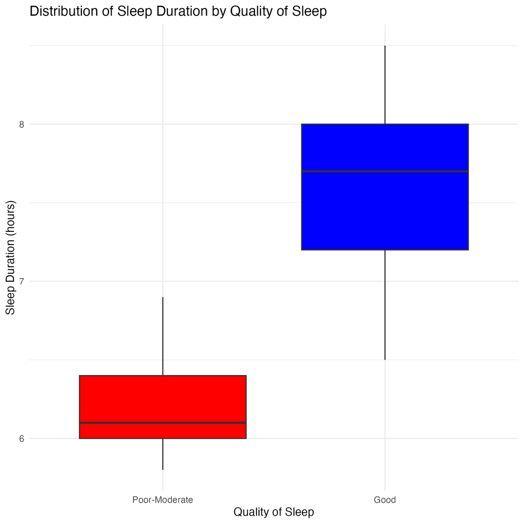

##### Figure 2: Proportion of Sleep Disorder by Quality of Sleep

This stacked bar plot illustrates the relationship between Sleep Disorder categories (None, Insomnia, Sleep Apnea) and Quality of Sleep (Poor-Moderate and Good). The height of each segment in the bars represents the proportion of individuals within each sleep disorder category for the respective quality of sleep level.

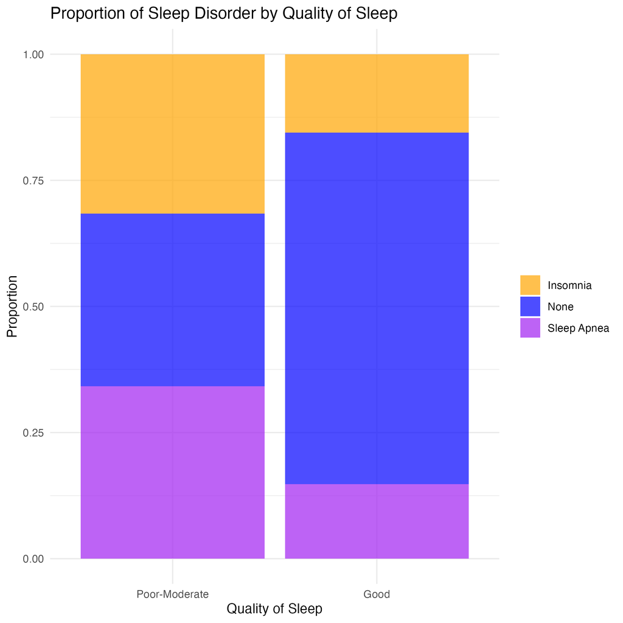